# Project3 - Titanic

Josh Chang

2018/4/30

# 1.簡介

這次的project，我們利用分析各種變數(ex:船票等級 性別 年齡等等)和存活率(survived)的關係，來預測其他在survived欄位中缺少的乘客，最後是否生還。在分析過程當中，運用到了非常多的圖表來說明和呈現我想表達的東西，後面的預測過程，我使用Random Forest 當作模型，來檢測我們預測的準確率為何。

# 2.分析過程

## 2.1 函數制定和讀取資料

```r
require(ggplot2)
library(ggplot2)
library(dplyr)
# 結合多張圖的函示(擷取自網路)
multiplot <- function(..., plotlist=NULL, file, cols=1, layout=NULL) {
  library(grid)

  # Make a list from the ... arguments and plotlist
  plots <- c(list(...), plotlist)

  numPlots = length(plots)

  # If layout is NULL, then use 'cols' to determine layout
  if (is.null(layout)) {
    # Make the panel
    # ncol: Number of columns of plots
    # nrow: Number of rows needed, calculated from # of cols
    layout <- matrix(seq(1, cols * ceiling(numPlots/cols)),
                     ncol = cols, nrow = ceiling(numPlots/cols))
  }

  if (numPlots==1) {
    print(plots[[1]])

  } else {
    # Set up the page
    grid.newpage()
    pushViewport(viewport(layout = grid.layout(nrow(layout), ncol(layout))))

    # Make each plot, in the correct location
    for (i in 1:numPlots) {
      # Get the i,j matrix positions of the regions that contain this subplot
      matchidx <- as.data.frame(which(layout == i, arr.ind = TRUE))

      print(plots[[i]], vp = viewport(layout.pos.row = matchidx$row,
                                      layout.pos.col = matchidx$col))
    }
  }
}

# 輸入資料
Titanic_data = read.csv("titanicTrain.csv")
Titanic_train = read.csv("titanicQuestion.csv")


# 將後面309筆空資料先移除
Titanic <- subset(Titanic_data, sex != "")
str(Titanic)
```

```
## 'data.frame':    1000 obs. of  14 variables:
##  $ pclass   : int  1 1 1 1 1 1 1 1 1 1 ...
##  $ survived : int  1 1 0 0 0 1 1 0 1 0 ...
##  $ name     : Factor w/ 999 levels "","Abbing, Mr. Anthony",..: 23 25 26 27 28 32 47 48 52 56 ...
##  $ sex      : Factor w/ 3 levels "","female","male": 2 3 2 3 2 3 2 3 2 3 ...
##  $ age      : num  29 0.917 2 30 25 ...
##  $ sibsp    : int  0 1 1 1 1 0 1 0 2 0 ...
##  $ parch    : int  0 2 2 2 2 0 0 0 0 0 ...
##  $ ticket   : Factor w/ 697 levels "","110152","110413",..: 188 51 51 51 51 125 94 17 78 617 ...
##  $ fare     : num  211 152 152 152 152 ...
##  $ cabin    : Factor w/ 181 levels "","A10","A11",..: 45 81 81 81 81 150 147 17 63 1 ...
##  $ embarked : Factor w/ 4 levels "","C","Q","S": 4 4 4 4 4 4 4 4 4 2 ...
##  $ boat     : Factor w/ 27 levels "","1","10","11",..: 12 4 1 1 1 13 3 1 27 1 ...
##  $ body     : int  NA NA NA 135 NA NA NA NA NA 22 ...
##  $ home.dest: Factor w/ 367 levels "","?Havana, Cuba",..: 307 230 230 230 230 236 161 24 22 228 ...
```

## 2.2 變數關係分析

### 2.2.1 乘客基本資料

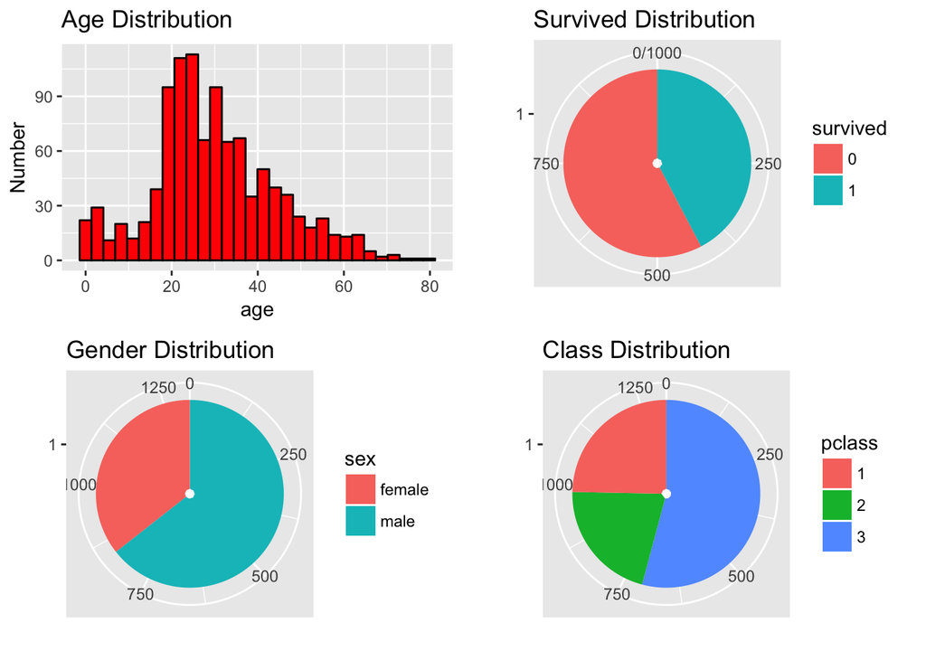

```r
Titanic$pclass = factor(Titanic$pclass)
Titanic$survived = factor(Titanic$survived)

Titanic_all <- rbind(Titanic,Titanic_train)
# 首先 讓我們先來看看這艘鐵達尼號上乘客最基本的資料

Titanic_all$age <- as.numeric(Titanic_all$age)
# age histogram plot
p1 <- ggplot(data = Titanic_all) +
  geom_histogram(aes(x = age),fill = "red",color = "black",
                  na.rm = TRUE) +
  ylab("Number") +
  ggtitle("Age Distribution")

# Gender Pie chart

p2 <- ggplot(data = Titanic_all) +
  geom_bar(aes(x = factor(1),fill = sex),
           stat = "count", na.rm = TRUE) +
  xlab("") + ylab("") + ggtitle("Gender Distribution") +
  # 再沿著Y，轉軸成圓餅圖
  coord_polar("y", start=0)

# Survived Pie chart

p3 <- ggplot(data = Titanic) +
  geom_bar(aes(x = factor(1),fill = survived),
           stat = "count", na.rm = TRUE) +
  xlab("") + ylab("") + ggtitle("Survived Distribution") +
  # 再沿著Y，轉軸成圓餅圖
  coord_polar("y", start=0)

# Pclass Pie chart

p4 <- ggplot(data = Titanic_all) +
  geom_bar(aes(x = factor(1),fill = pclass),
           stat = "count", na.rm = TRUE) +
  xlab("") + ylab("") + ggtitle("Class Distribution") +
  # 再沿著Y，轉軸成圓餅圖
  coord_polar("y", start=0)

#將四張圖合併輸出
multiplot(p1, p2, p3, p4,cols=2)
```

我們在分析基本資料時 是使用兩筆資料合起來 總計1309位乘客的資料 而存活率則是只使用1000位乘客的資料 因為另外309位的存活率目前未知 因此在後面的討論 大部分也是先行使用只有1000位乘客的 titanicTrain.csv 提供的資料

上面四個圖可以發現 乘客的年齡大約集中在20 ~ 40歲 而男女比接近3:2

而當中乘客的存活率大約為2:3 座艙的等級分布則是 25 %, 20 % 和 55 % (由好至壞)

### 2.2.2 性別存活率

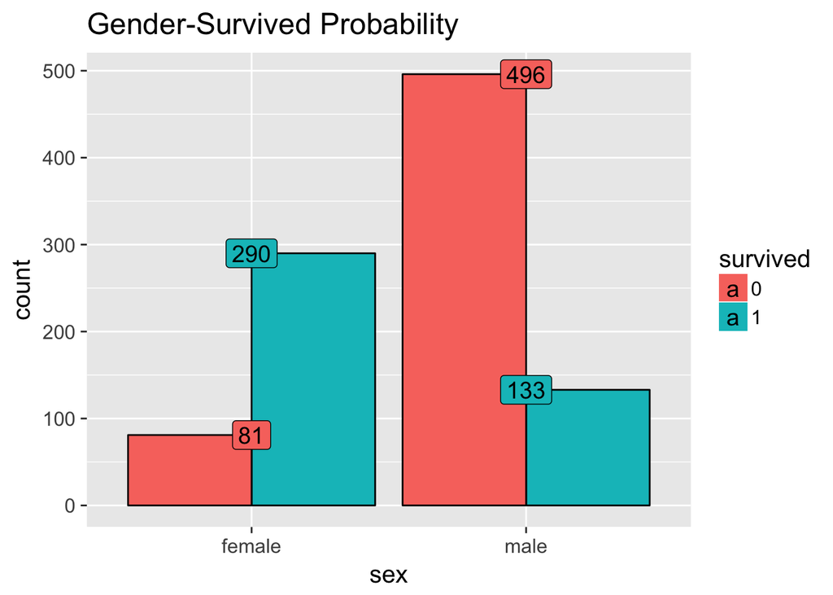

```r
# 接下來 我們就要來探討 各項數據和存活率的關係
# 首先 我們先來看看不同性別的存活率
ggplot(data = Titanic) +
  geom_bar(aes(x = sex,fill = survived),color = "black", position="dodge") +
  geom_label(stat = "count",aes(x = sex,fill = survived,label = ..count..),
             size=5) +
  theme_grey(base_size = 15) +
  ggtitle("Gender-Survived Probability")
```

可以發現男性的存活率大約只有20% 而女性則有約80%的存活率

由此可知 當時發生危險 可能都是先將救生艇的位置讓給了女性

### 2.2.3 船票等級與存活率的關係

在pclass中 數字越小 代表等級越高(類似我們頭等艙 經濟艙的概念)

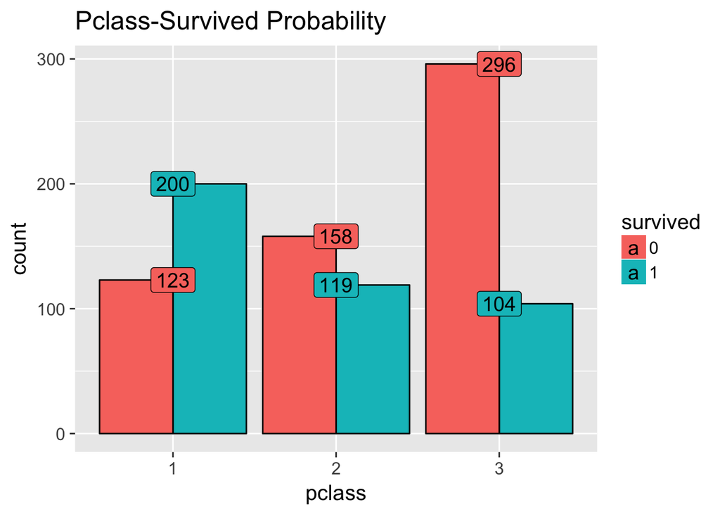

```r
ggplot(data = Titanic) +
  geom_bar(aes(x = pclass,fill = survived),color = "black", position="dodge") +
  geom_label(stat = "count",aes(x = pclass,fill = survived,label = ..count..),
             size=5) +
  theme_grey(base_size = 15) +
  ggtitle("Pclass-Survived Probability")
```

可以發現 坐在1號船票乘客的存活率超過了60% 而2號船票 存活率大概在40~50%左右 3號船票就比較慘了 僅有大約25%的存活率 有此也可知 坐在較高等級傳票的乘客 也就是比較有錢的乘客 擁有了較多的機會逃生

### 2.2.4 性別 船票等級 存活率三者關係

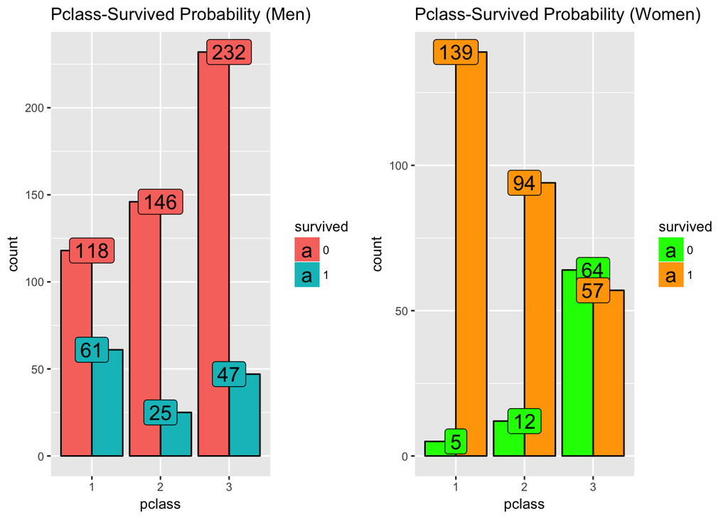

```r
Titanic_men <- subset(Titanic,sex == "male")
Titanic_women <- subset(Titanic,sex == "female")

p5 <- ggplot(data = Titanic_men) +
  geom_bar(aes(x = pclass,fill = survived),color = "black", position="dodge") +
  geom_label(stat = "count",aes(x = pclass,fill = survived,label = ..count..),
             size=5) +
  theme_grey(base_size = 10) +
  ggtitle("Pclass-Survived Probability (Men)")

p6 <- ggplot(data = Titanic_women) +
  geom_bar(aes(x = pclass,fill = survived),color = "black", position="dodge") +
  geom_label(stat = "count",aes(x = pclass,fill = survived,label = ..count..),
             size=5) +
  theme_grey(base_size = 10) +
  scale_fill_manual(values=c('green','orange'))+ #颜色
  ggtitle("Pclass-Survived Probability (Women)")

multiplot(p5,p6,cols=2)
```

這邊大概可以很清楚的知道 最後獲救的人 大多是 較有錢的女性

### 2.2.5 港口跟存活率的關係

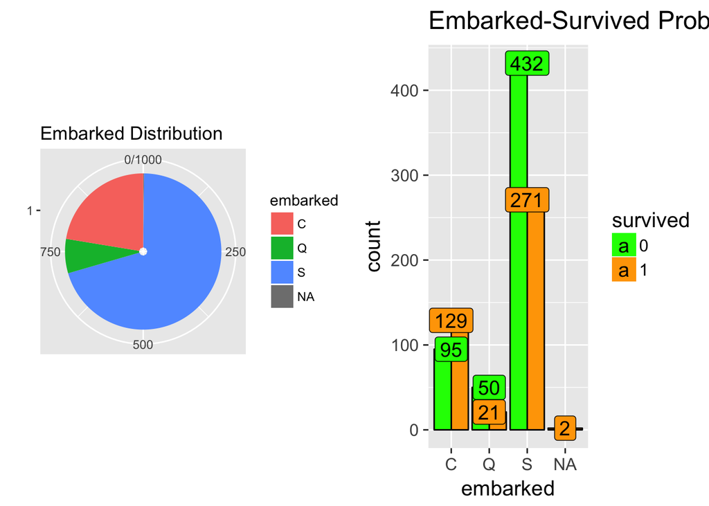

```r
Titanic$embarked = as.character(Titanic$embarked)
a <- c()
for(i in c(1:1000)){
  if(Titanic$embarked[i] == ""){
    Titanic$embarked[i] = NA
    a <- c(a,i)
  }
}

p7 <- ggplot(data = Titanic) +
  geom_bar(aes(x = factor(1),fill = embarked),
           stat = "count", na.rm = TRUE) +
  xlab("") + ylab("") + ggtitle("Embarked Distribution") +
  # 再沿著Y，轉軸成圓餅圖
  coord_polar("y", start=0)

p8 <- ggplot(data = Titanic) +
  geom_bar(aes(x = embarked,fill = survived),color = "black", position="dodge", na.rm = TRUE) +
  geom_label(stat = "count",aes(x = embarked,fill = survived,label = ..count..),
             size=5) +
  theme_grey(base_size = 15) +
  scale_fill_manual(values=c('green','orange'))+ #颜色
  ggtitle("Embarked-Survived Probability")

multiplot(p7,p8,cols=2)
```

這邊看到 大約有七成的人從港口S搭船 但存活率大約只有四成

而從C港口搭船的乘客存活率最高 超過了五成 而 Q港口 搭乘人數和存活率皆為最低

### 2.2.6 上岸港口與船票等級的關係

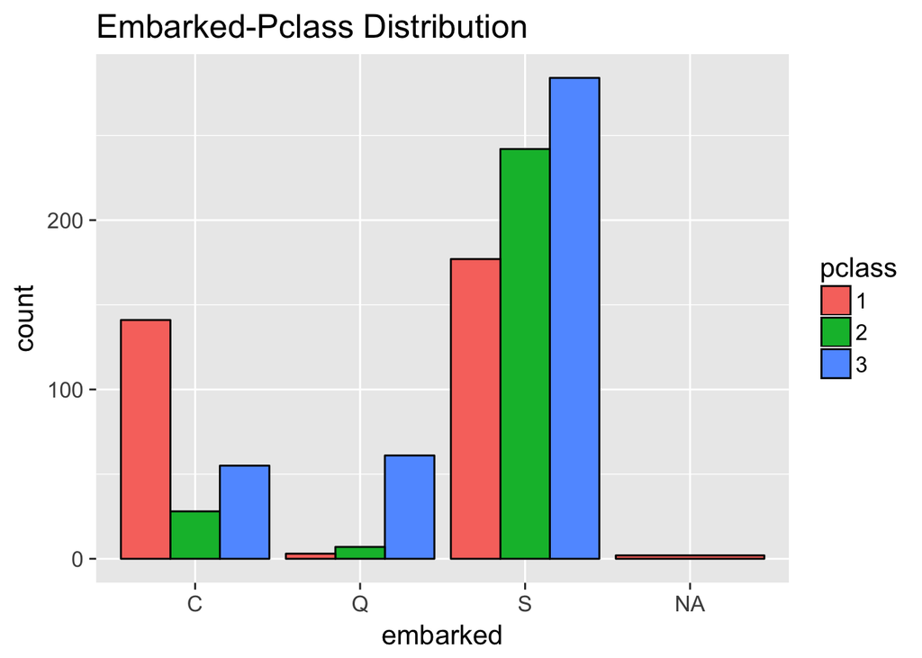

```r
ggplot(data = Titanic) +
  geom_bar(aes(x = embarked,fill = pclass),color = "black", position="dodge") +
  theme_grey(base_size = 15) +
  ggtitle("Embarked-Pclass Distribution")
```

```r
Titanic$embarked[a] <- 'C'
```

我們可看出不同港口乘客有不同的經濟狀況。從C港口上船的目的主要可能為旅遊，因此多購買等級最高的P1船票（也使得C港口上船的有較高的存活率），來自Q港口的乘客則有極大的比例是購買最低等級的P3船票，目的可能為工作或移民。

也可以從中看到缺乏港口乘客的pclass = 1 因此 我們在後面也會將合併資料中的港口填補為C

### 2.2.7 船票價錢跟存活率的關係

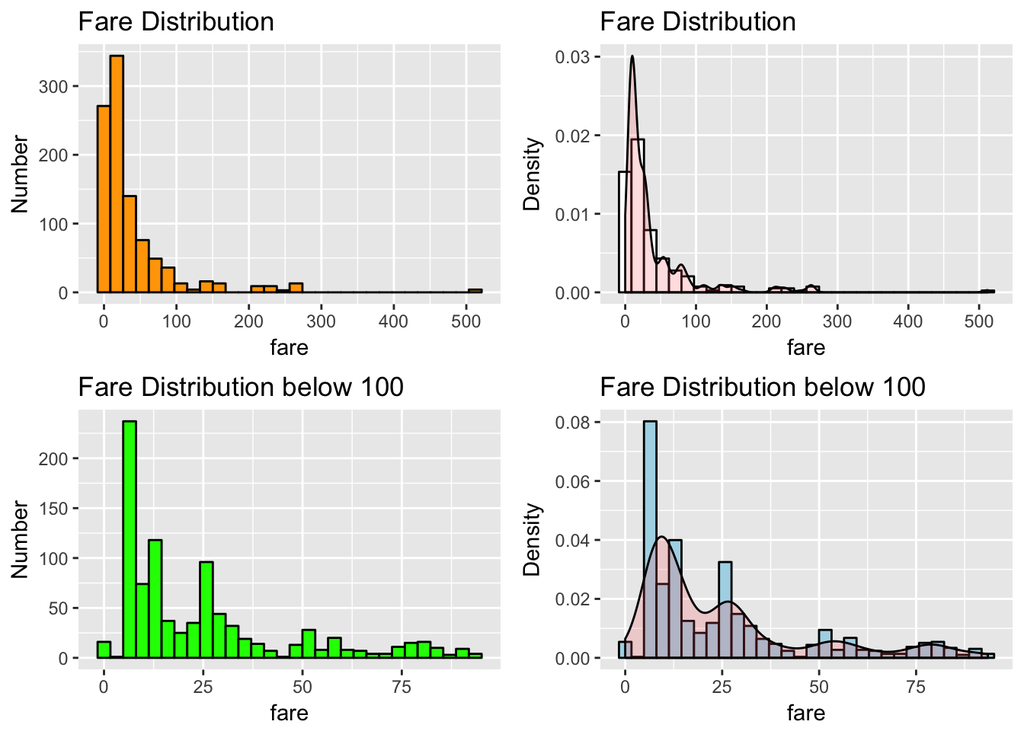

```r
Titanic_fare100 <- subset(Titanic,fare <= 100)

# Fare histogram plot
p9 <- ggplot(data = Titanic) +
  geom_histogram(aes(x = fare),fill = "Orange",color = "black",bins = 30, na.rm = TRUE) +
  ylab("Number") + ggtitle("Fare Distribution")


p10 <- ggplot(data = Titanic_fare100) +
  geom_histogram(aes(x = fare),fill = "Green",color = "black",bins = 30, na.rm = TRUE) +
  ylab("Number") + ggtitle("Fare Distribution below 100")

p11 <- ggplot(data = Titanic) +
  geom_histogram(aes(x = fare, y=..density..),fill = "White",color = "black",bins = 30, na.rm = TRUE) +
  ylab("Density") + ggtitle("Fare Distribution") +
  geom_density(aes(x = fare),alpha=.2, fill="#FF6666")


p12 <- ggplot(data = Titanic_fare100) +
  geom_histogram(aes(x = fare, y=..density..),fill = "Light Blue",color = "black",bins = 30, na.rm = TRUE) +
  ylab("Density") + ggtitle("Fare Distribution below 100") +
  geom_density(aes(x = fare),alpha=.2, fill="#FF6666")

multiplot(p9,p10,p11,p12,cols=2)
```

首先這四張是 船票的票價直方圖 和 直方圖跟機率密度結合的圖

可以看到大部分的票價是在 100 元以內 因此 另外做了一份100元以內的票價分佈圖

最終發現 票價最多分佈在 25 元以內

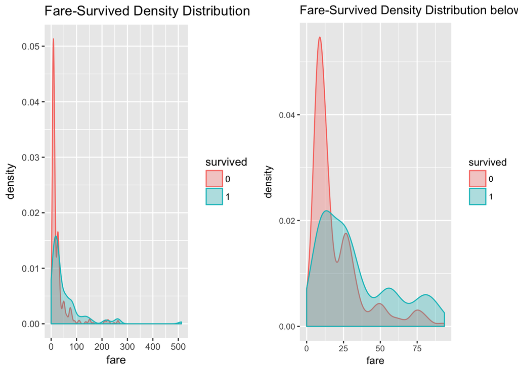

```r
p13 <- ggplot(Titanic, aes(x=fare,color = survived,fill = survived)) +
  geom_density(aes(x = fare),alpha=.3) +
  ggtitle("Fare-Survived Density Distribution")

p14 <- ggplot(Titanic_fare100, aes(x=fare,color = survived,fill = survived)) +
  geom_density(aes(x = fare),alpha=.3) +
  ggtitle("Fare-Survived Density Distribution below 100") +
  theme_grey(base_size = 10)

multiplot(p13,p14,cols=2)
```

從這兩張機率密度圖可發現 在票價低於25元的乘客中 存活率相較於其他價錢低很多

### 2.2.8 船票錢 年齡 和生存率的探討

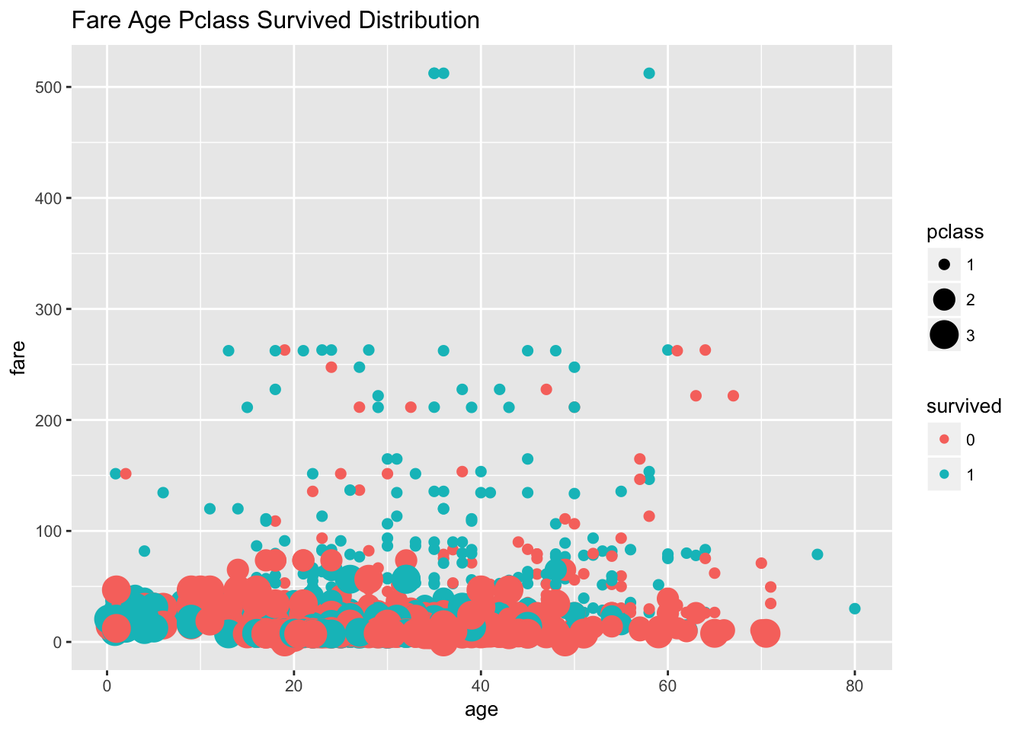

```r
ggplot(data = Titanic) +
  geom_point(aes(x = age,y = fare, colour = survived, size = pclass)) +
  ggtitle("Fare Age Pclass Survived Distribution") +
  theme_grey(base_size = 10)
```

從這張多變數的點圖中 我們看到生存率和船票的價錢以及船票的等級都非常有關聯 越便宜的票 通常也帶表 他船票的等級較低 不過這張圖也看出 年齡跟船票等級 船票價錢較無明顯的關聯

### 2.2.9 家人和存活率之間的關係

sibsp為在船上同為兄弟姐妹或配偶的數目 parch為在船上同為家族的父母及小孩的數目 由於我初估判斷兩者的影響力可能差不多 所以 我們在當中新增一個欄位名為 family(家人數) 來探討跟存活率之間的關係

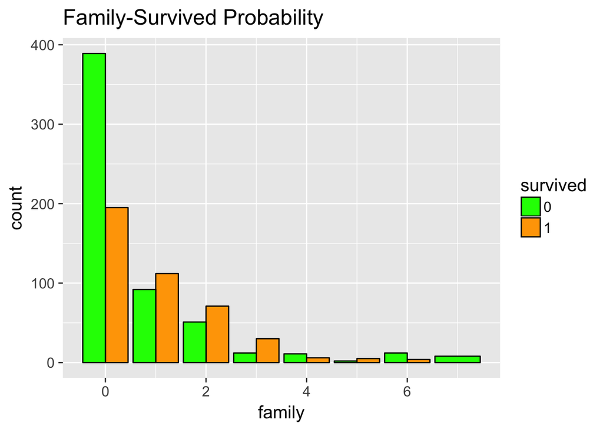

```r
Titanic$family <- Titanic$sibsp + Titanic$parch
Titanic_all$family <- Titanic_all$sibsp + Titanic_all$parch

ggplot(data = Titanic) +
  geom_bar(aes(x = family,fill = survived),color = "black", position="dodge") +
  theme_grey(base_size = 15) +
  scale_fill_manual(values=c('green','orange'))+ #颜色
  ggtitle("Family-Survived Probability")
```

```r
filter(Titanic) %>%
  group_by(family) %>%
  summarise(Survived = sum(as.numeric(survived) - 1) / length(survived) )
```

```
## # A tibble: 8 x 2
##   family Survived
##    <int>    <dbl>
## 1      0    0.334
## 2      1    0.549
## 3      2    0.582
## 4      3    0.714
## 5      4    0.353
## 6      5    0.714
## 7      6    0.250
## 8      7    0.
```

發現有家人一起搭船的乘客 存活的比率明顯比獨自一人搭船的乘客高

存活率最高的分別是 有3和5位家人的乘客

### 2.2.10 探討稱謂和存活率的關係 以及將較少出現的稱謂合併

```r
b <- list()
call <- c()
Titanic_all$name <- as.character(Titanic_all$name)

for (i in c(1:1309)){
  b[[i]] <- strsplit(Titanic_all$name[i], "[,.]")
}
b[[5]][[1]][2]
```

```
## [1] " Mrs"
```

```r
for(i in c(1:1309)){
  Titanic_all$Title[i] <- b[[i]][[1]][2]
}

filter(Titanic_all) %>%
  group_by(Title) %>%
  summarise(Num = length(Title), Sex = (sum(as.numeric(sex) - 2) ) / length(sex), Survived = sum(as.numeric(survived)) / length(survived), Age = sum(age,na.rm=TRUE) / length(age))
```

```
## # A tibble: 18 x 5
##    Title             Num   Sex Survived   Age
##    <chr>           <int> <dbl>    <dbl> <dbl>
##  1 " Capt"             1 1.00      1.00 70.0
##  2 " Col"              4 1.00      1.50 54.0
##  3 " Don"              1 1.00      1.00 40.0
##  4 " Dona"             1 0.        2.00 39.0
##  5 " Dr"               8 0.875     1.50 38.1
##  6 " Jonkheer"         1 1.00      1.00 38.0
##  7 " Lady"             1 0.        2.00 48.0
##  8 " Major"            2 1.00      1.50 48.5
##  9 " Master"          61 1.00     NA     4.76
## 10 " Miss"           260 0.       NA    17.6
## 11 " Mlle"             2 0.        2.00 24.0
## 12 " Mme"              1 0.        2.00 24.0
## 13 " Mr"             757 1.00     NA    24.8
## 14 " Mrs"            197 0.       NA    31.9
## 15 " Ms"               2 0.       NA    14.0
## 16 " Rev"              8 1.00      1.00 41.2
## 17 " Sir"              1 1.00      2.00 49.0
## 18 " the Countess"     1 0.        2.00 33.0
```

```r
for(i in c(1:1309)){
  if(Titanic_all$Title[i] == " Mr" &&  is.na(Titanic_all$age[i])){
    Titanic_all$Title[i] <- "Men"}
  else if(Titanic_all$Title[i] == " Mr"  && Titanic_all$age[i] <= 40){
    Titanic_all$Title[i] <- "Young Men"}
  else if(Titanic_all$Title[i] == " Mr"  && Titanic_all$age[i] > 40){
    Titanic_all$Title[i] <- "Old Men"}
  if(Titanic_all$Title[i] == " Capt" || Titanic_all$Title[i] == " Col" || Titanic_all$Title[i] == " Major" || Titanic_all$Title[i] == " Major" || Titanic_all$Title[i] == " Sir"){
    Titanic_all$Title[i] <- "Old Men"}
  if(Titanic_all$Title[i] == " Don" || Titanic_all$Title[i] == " Rev" || Titanic_all$Title[i] == " Jonkheer"){
    Titanic_all$Title[i] <- "Young Men"}
  if(Titanic_all$Title[i] == " Dona" || Titanic_all$Title[i] == " Lady" || Titanic_all$Title[i] == " Ms" || Titanic_all$Title[i] == " the Countess" || Titanic_all$Title[i] == " Mrs"){
    Titanic_all$Title[i] <- "Mrs"}
  if(Titanic_all$Title[i] == " Mlle" || Titanic_all$Title[i] == " Mme" || Titanic_all$Title[i] == " Miss"){
    Titanic_all$Title[i] <- " Miss"}
}

filter(Titanic_all) %>%
  group_by(Title) %>%
  summarise(Num = length(Title), Sex = (sum(as.numeric(sex) - 2) ) / length(sex), Survived = sum(as.numeric(survived) ) / length(survived), Age = sum(age,na.rm=TRUE) / length(age))
```

```
## # A tibble: 7 x 5
##   Title       Num   Sex Survived   Age
##   <chr>     <int> <dbl>    <dbl> <dbl>
## 1 " Dr"         8 0.875     1.50 38.1
## 2 " Master"    61 1.00     NA     4.76
## 3 " Miss"     263 0.       NA    17.7
## 4 Men         176 1.00     NA     0.
## 5 Mrs         202 0.       NA    31.9
## 6 Old Men     140 1.00     NA    51.2
## 7 Young Men   459 1.00     NA    27.0
```

# 3. 特徵工程和訓練

## 3.1 補齊缺失值

### 3.1.1 港口

從前面2.2.6 我們看到缺乏港口乘客的pclass = 1 而由於跟其他港口相比 從C港口中出發的pclass = 1的乘客比率最高 因此 我們將他的港口填補為C

```r
Titanic_all$embarked[a] <- 'C'
```

### 3.1.2 票價

```r
sum(is.na(Titanic_all$fare))
```

```
## [1] 1
```

```r
for(i in c(1:1309)){
  if(is.na(Titanic_all$fare[i]) == TRUE){
    t <- i}
}
Titanic_all[t,]
```

```
##      pclass survived               name  sex  age sibsp parch ticket fare
## 1226      3     <NA> Storey, Mr. Thomas male 60.5     0     0   3701   NA
##      cabin embarked boat body home.dest family   Title
## 1226              S       261                0 Old Men
```

```r
filter(Titanic_all) %>%
  group_by(embarked) %>%
  summarise(Num = length(name), Sex = (sum(as.numeric(sex) - 2) ) / length(sex), Age = sum(age,na.rm=TRUE) / length(age),Fare = median(fare,na.rm = T))
```

```
## # A tibble: 3 x 5
##   embarked   Num   Sex   Age  Fare
##   <fct>    <int> <dbl> <dbl> <dbl>
## 1 C          272 0.577  25.6 28.6
## 2 Q          123 0.512  11.6  7.75
## 3 S          914 0.682  25.0 13.0
```

```r
filter(Titanic_all) %>%
  group_by(pclass) %>%
  summarise(Num = length(name), Sex = (sum(as.numeric(sex) - 2) ) / length(sex), Age = sum(age,na.rm=TRUE) / length(age),Fare = median(fare,na.rm = T))
```

```
## # A tibble: 3 x 5
##   pclass   Num   Sex   Age  Fare
##   <fct>  <int> <dbl> <dbl> <dbl>
## 1 1        323 0.554  34.4 60.0
## 2 2        277 0.617  27.8 15.0
## 3 3        709 0.695  17.5  8.05
```

```r
Titanic_all$fare[t] = 10.5
```

我們首先先發現 因為fare只有一筆資料為NA 所以我們找到其是第1226筆 並且觀察這位乘客的資料 發現他是一個年老的男性 且他的船票等級為第3等 出發港口位於 S 港

但由於我們在2.2.8的分析中發現 年齡對於船票價錢的影響性不高

於是我們只來查看港口和船票等級的影響 發現 船票等級為3的票價中位數為8.05 而由S港出發的票價中位數為13.0 因為 這兩項數據代表的乘客都很多 我就相信這樣的資訊是可靠且平等 因此我將這兩個值取平均 得到值為 10.5

### 3.1.3 年齡

```r
sum(is.na(Titanic_all$fare))
```

```
## [1] 0
```

```r
require(missForest)
require(mice)
factor_vars <- c('pclass','sex','age','embarked','family',"Title")
Titanic_all[factor_vars] <- lapply(Titanic_all[factor_vars],function(x) as.factor(x))
# 設置隨機種子
set.seed(129)
# 執行多重插補法，剔除一些沒什麼用的變量:
mice_mod <- mice(Titanic_all[, !names(Titanic_all) %in% c('name','ticket','cabin','survived','boat','body','home.dest')], method='rf')
```

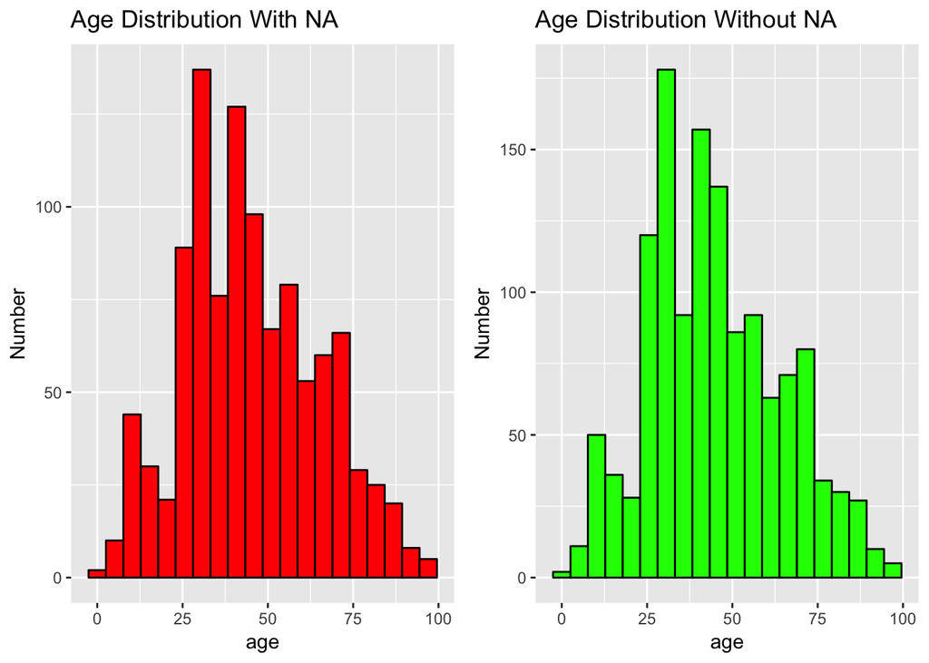

```r
mice_output <- complete(mice_mod)
mice_output$age <- as.numeric(mice_output$age)
Titanic_all$age <- as.numeric(Titanic_all$age)

p16 <- ggplot(data = mice_output) +
  geom_histogram(aes(x = age),fill = "green",color = "black",
                 bins = 20, na.rm = TRUE) +
  ylab("Number") +
  ggtitle("Age Distribution Without NA")

p15 <- ggplot(data = Titanic_all) +
  geom_histogram(aes(x = age),fill = "red",color = "black",
                 bins = 20, na.rm = TRUE) +
  ylab("Number") +
  ggtitle("Age Distribution With NA")

multiplot(p15,p16,cols = 2)
```

```r
Titanic_all$age = mice_output$age
```

我們用底下兩張圖 發現結果非常好 用mice包填補數據Age後 數據分佈沒有發生偏移 於是我們便可以將mice_output裡面的age換掉原本Titanic_all裡面的Age了～

## 3.2 建立模型(Random Forest)

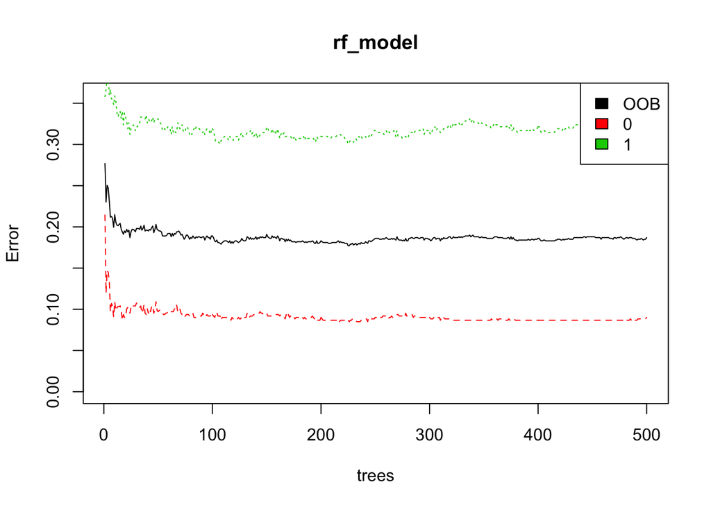

```r
train <- Titanic_all[1:1000,]
test <- Titanic_all[1001:1309,]
set.seed(754)
rf_model <- randomForest(factor(survived) ~ pclass + sex + age + sibsp + fare + embarked + family + Title , data = train)
# 顯示模型誤差
plot(rf_model, ylim=c(0,0.36))
legend('topright', colnames(rf_model$err.rate), col=1:3, fill=1:3)
```

我們利用訓練集訓練Random-Forest模型

上面那張圖中 黑色那條線表示：整體誤差率（the overall error rate）低於20% 紅色和綠色分別表示：遇難與生還的誤差率 因此我們可以說

相對於生還來說，我們可以更準確的預測出死亡。

## 3.3 預測結果

```r
prediction1 <- predict(rf_model,test)
prediction2 <- predict(rf_model,train)
success <- 0
for(i in c(1:1000)){
  if(prediction2[i] == Titanic_all$survived[i]){
    success <- success + 1
  }
}
print(success / 1000)
```

```
## [1] 0.889
```

```r
solution <- data.frame(survived = prediction1)
write.csv(solution,file = 'rf_mod_Solution.csv')
```

最後我們將test和train同時放入model中，並且看看train中的正確率，結果發現為0.889，因此就放心的把test的結果輸出，完成了這次的Project：）

# 4.結論

這次的Titanic分析 花了我滿長的一段時間，尤其是因為上禮拜感冒請假，沒有聽到上課的內容讓我對這次的主題不是很清楚，不過藉由查詢網路資料，也從中逐漸了解這次主題的目標。我覺得我這次學習到最多的便是使用各種視覺化的圖表，不管是密度圖 圓餅圖 直方圖 等等，很多都是我之前沒有嘗試過的，我也在參考網路的資源中，學習到如何用label，讓圖形更清楚的使別人理解我想表達的東西。

最後的結果擁有將近九成的準確率讓我有點小驚訝，但想到本身model就是用train本身建的，所以真的test的結果可能就不會像train本身那麼高了。

這次覺得比較可惜的部分可能就是因為還有其他科期中考，所以沒辦法花更多時間在使用不同model來預測我的資料，只能選用網路上較多且比較容易的Random Forest模型，不過我相信以後仍然會有許多時間鑽研機器學習的部分的！